# Correlaciones por pares

María Sánchez Vivo

2026-05-25

# **Introducción**

El análisis de correlaciones entre variables clínicas, metabolitos y bacterias se realizó empleando distintos métodos estadísticos según la naturaleza de las variables comparadas. Para las **asociaciones entre variables numéricas se utilizó la correlación de Spearman** mediante la función Hmisc::rcorr, mientras que las **asociaciones entre variables categóricas se evaluaron mediante el estadístico V de Cramér** usando vcd::assocstats. En los casos en los que se analizaron **variables numéricas frente a variables categóricas dicotómicas, se aplicó la correlación de Pearson punto-biserial**. Las variables numéricas no fueron escaladas previamente, ya que la correlación de Spearman se basa en rangos y, por tanto, el escalado resulta redundante, mientras que la correlación punto-biserial de Pearson es invariante frente a transformaciones lineales. Para controlar el error asociado a comparaciones múltiples, los valores de p se ajustaron mediante corrección FDR (Benjamini–Hochberg), aplicada de forma global a cada bloque de correlaciones antes de seleccionar aquellas consideradas significativas.

## Carga de datos y preparación del dataset integrado

En este apartado se cargan las librerías necesarias y se importan los distintos conjuntos de datos correspondientes a metabolitos, microbiota y variables clínicas. Después, se integran en un único marco de análisis, eliminando variables redundantes y asegurando la correcta alineación de muestras. A continuación, se construyen las matrices finales de trabajo para variables clínicas, metabolitos y bacterias filtradas, además de definir subconjuntos de variables numéricas y categóricas relevantes para el análisis de correlaciones.

```r
library(Hmisc)
library(vcd)
library(corrplot)
library(tidyverse)
library(mia)
library(TreeSummarizedExperiment)

#Carga de datos
datos_metabolitos     <- readRDS("metabolitos.rds")
datos_metataxonomicos <- readRDS("tax.rds")
datos_clinicos        <- readRDS("covs.rds")
datos_abundancia_16S  <- readRDS("metagen.rds")

datos_clinicos_limpios <- datos_clinicos %>%
  as.data.frame() %>%
  select(-ends_with("_0"))

datos_clinicos_metabolomicos <- merge(
  datos_clinicos_limpios,
  datos_metabolitos,
  by = "Sample"
)

nombres_metabolitos <- names(datos_metabolitos)[
  names(datos_metabolitos) != "Sample"
]
```

## Construcción de la matriz microbiana y filtrado de géneros

A continuación, se reconstruye el objeto de microbiota a partir de las abundancias originales, transformándolo a abundancia relativa y agrupándolo a nivel de género. Después, se filtran los taxones menos informativos en función de criterios de prevalencia y abundancia media, reduciendo ruido y mejorando la potencia estadística del análisis.

```r
# Reconstruir TSE y tse_genus ───────────────────────────────────────────────
counts_prepared <- datos_abundancia_16S %>%
  column_to_rownames("Sample") %>%
  t() %>%
  as.matrix()

colnames(counts_prepared) <- trimws(colnames(counts_prepared))

datos_clinicos_mia <- as.data.frame(datos_clinicos)
rownames(datos_clinicos_mia) <- trimws(
  as.character(datos_clinicos_mia$Sample)
)

tax_prepared <- datos_metataxonomicos %>%
  as.data.frame() %>%
  as.matrix()

rownames(tax_prepared) <- trimws(rownames(tax_prepared))

comun_muestras <- intersect(
  colnames(counts_prepared),
  rownames(datos_clinicos_mia)
)

counts_filtrado  <- counts_prepared[, comun_muestras]
clinicos_final   <- datos_clinicos_mia[comun_muestras, ]
comun_taxones    <- intersect(rownames(counts_filtrado), rownames(tax_prepared))
counts_final     <- counts_filtrado[comun_taxones, ]
tax_final        <- tax_prepared[comun_taxones, ]

tse <- TreeSummarizedExperiment(
  assays  = list(counts = as.matrix(counts_final)),
  colData = DataFrame(clinicos_final),
  rowData = DataFrame(tax_final)
)

tse        <- transformAssay(tse, method = "relabundance")
tse_genus  <- agglomerateByRank(tse, rank = "Genus")
tse_genus  <- tse_genus[rowData(tse_genus)$Genus != "", ]
tse_genus  <- transformAssay(tse_genus, method = "relabundance")


# Filtrar géneros prevalentes ───────────────────────────────────────────────
# Umbral: prevalencia ≥ 20 % de muestras Y abundancia relativa media ≥ 0.1 %
# Elimina géneros raros que solo aportarían ruido y tests sin potencia

prevalencia <- rowMeans(assay(tse_genus, "relabundance") > 0)
abund_media <- rowMeans(assay(tse_genus, "relabundance"))
generos_filt  <- names(which(prevalencia >= 0.2 & abund_media >= 0.001))
tse_genus_filt <- tse_genus[generos_filt, ]
mat_bacterias  <- t(assay(tse_genus_filt, "relabundance"))


# Alinear muestras ──────────────────────────────────────────────────────────
muestras_comun <- intersect(
  rownames(mat_bacterias),
  datos_clinicos_metabolomicos$Sample
)

mat_bacterias_al <- mat_bacterias[muestras_comun, ]

df_base <- datos_clinicos_metabolomicos %>%
  filter(Sample %in% muestras_comun) %>%
  arrange(match(Sample, muestras_comun))
```

## Selección y estructuración de variables clínicas

En este apartado se identifican y separan las variables clínicas en numéricas y categóricas binarias, eliminando aquellas con baja variabilidad. Posteriormente, se alinean todas las matrices (clínica, metabolómica y bacteriana) para asegurar la comparabilidad entre muestras en los análisis de correlación.

```r
# Selección de variables clínicas
vars_id <- c("Sample", "diagnostico_principal")

# Variables numéricas
vars_num_clin <- df_base %>%
  select(-all_of(vars_id), -all_of(nombres_metabolitos)) %>%
  select(where(is.numeric)) %>%
  select(where(~ n_distinct(., na.rm = TRUE) >= 2)) %>%
  names()

# Variables categóricas binarias
vars_cat_clin <- df_base %>%
  select(-all_of(vars_id), -all_of(nombres_metabolitos)) %>%
  select(where(~ is.factor(.) | is.character(.))) %>%
  select(where(~ n_distinct(., na.rm = TRUE) == 2)) %>%
  names()


# Matrices finales ──────────────────────────────────────────────────────────
mat_num_clin <- as.matrix(df_base[, vars_num_clin])
mat_met      <- as.matrix(df_base[, nombres_metabolitos])
mat_bact     <- mat_bacterias_al

# Variables categóricas: se preserva el factor tal como viene
mat_cat_clin <- df_base %>%
  select(all_of(vars_cat_clin)) %>%
  mutate(across(everything(), as.factor))

cat("Variables clínicas numéricas:", length(vars_num_clin), "\n")
```

```
## Variables clínicas numéricas: 34
```

```r
cat("Variables clínicas categóricas binarias:", length(vars_cat_clin), "\n")
```

```
## Variables clínicas categóricas binarias: 84
```

```r
cat("Metabolitos:", length(nombres_metabolitos), "\n")
```

```
## Metabolitos: 53
```

```r
cat("Géneros filtrados:", ncol(mat_bact), "\n")
```

```
## Géneros filtrados: 35
```

```r
cat("Muestras comunes:", length(muestras_comun), "\n")
```

```
## Muestras comunes: 46
```

# **Funciones de correlación**

A continuación, se definen las funciones necesarias para calcular las distintas asociaciones entre variables según su naturaleza. Se incluye una función de seguridad para variables binarias que evita errores de codificación. Después, se implementan funciones específicas para **correlaciones de Spearman (numéricas), V de Cramer (categóricas) y Pearson punto-biserial (numéricas vs binarias)**, además de una función integradora que construye matrices completas de correlación y aplica **corrección por FDR** para controlar el error por múltiples comparaciones.

```r
safe_binary_num <- function(x) {
  x <- as.factor(x)
  lvls <- levels(x)
  if (length(lvls) != 2) {
    stop("safe_binary_num: la variable no es binaria (", length(lvls), " niveles)")
  }
  # nivel[1] → 0  (NO)
  # nivel[2] → 1  (SÍ)
  as.integer(x == lvls[2])
}


# Spearman entre matrices numéricas ─────────────────────────────────────────
spearman_block <- function(mat_x, mat_y) {

  res <- rcorr(mat_x, mat_y, type = "spearman")
  nx  <- ncol(mat_x)
  ny  <- ncol(mat_y)

  list(
    r = res$r[1:nx, (nx + 1):(nx + ny), drop = FALSE],
    p = res$P[1:nx, (nx + 1):(nx + ny), drop = FALSE]
  )
}


# Cramér's V entre variables categóricas: está en el rango [0, 1], por ello is.corr = FALSE, para que la escala de colores no se centre en 0 de forma engañosa.
# En heatmap, los valores altos (rojo) indican asociación fuerte sin información sobre la dirección.

cramer_block <- function(cat_x, cat_y) {

  r_mat <- matrix(
    NA,
    nrow = ncol(cat_x), ncol = ncol(cat_y),
    dimnames = list(names(cat_x), names(cat_y))
  )
  p_mat <- r_mat

  for (i in names(cat_x)) {
    for (j in names(cat_y)) {

      tab <- table(cat_x[[i]], cat_y[[j]])
      if (nrow(tab) < 2 || ncol(tab) < 2) next

      as_  <- assocstats(tab)
      r_mat[i, j] <- as_$cramer
      p_mat[i, j] <- chisq.test(
        tab,
        simulate.p.value = TRUE,
        B = 2000
      )$p.value
    }
  }

  list(r = r_mat, p = p_mat)
}


# Pearson: numéricas × categóricas binarias ──────────────────
# Usa safe_binary_num() para garantizar que la dirección del coeficiente

pearson_num_cat <- function(mat_num, cat_df) {

  r_mat <- matrix(
    NA,
    nrow = ncol(mat_num), ncol = ncol(cat_df),
    dimnames = list(colnames(mat_num), names(cat_df))
  )
  p_mat <- r_mat

  for (num_v in colnames(mat_num)) {
    for (cat_v in names(cat_df)) {

      cat_num <- safe_binary_num(cat_df[[cat_v]])

      if (var(cat_num, na.rm = TRUE) == 0) next

      test <- cor.test(
        mat_num[, num_v],
        cat_num,
        method = "pearson"
      )

      r_mat[num_v, cat_v] <- test$estimate
      p_mat[num_v, cat_v] <- test$p.value
    }
  }

  list(r = r_mat, p = p_mat)
}


# Ensamblar matriz combinada (num + cat en cada eje) ────────────────────────
construir_matriz_combinada <- function(
    bloque_num_x,
    bloque_cat_x,
    bloque_num_y,
    bloque_cat_y
) {

  resultados <- list()

  if (!is.null(bloque_num_x) && !is.null(bloque_num_y))
    resultados[["nn"]] <- spearman_block(bloque_num_x, bloque_num_y)

  if (!is.null(bloque_cat_x) && !is.null(bloque_cat_y))
    resultados[["cc"]] <- cramer_block(bloque_cat_x, bloque_cat_y)

  if (!is.null(bloque_num_x) && !is.null(bloque_cat_y))
    resultados[["nc"]] <- pearson_num_cat(bloque_num_x, bloque_cat_y)

  if (!is.null(bloque_cat_x) && !is.null(bloque_num_y))
    resultados[["cn"]] <- pearson_num_cat(bloque_num_y, bloque_cat_x)

  vars_x <- c(
    if (!is.null(bloque_num_x)) colnames(bloque_num_x),
    if (!is.null(bloque_cat_x)) names(bloque_cat_x)
  )
  vars_y <- c(
    if (!is.null(bloque_num_y)) colnames(bloque_num_y),
    if (!is.null(bloque_cat_y)) names(bloque_cat_y)
  )

  r_full <- matrix(0, nrow = length(vars_x), ncol = length(vars_y),
                   dimnames = list(vars_x, vars_y))
  p_full <- matrix(1, nrow = length(vars_x), ncol = length(vars_y),
                   dimnames = list(vars_x, vars_y))

  rellenar <- function(mat, bloque, filas, cols) {
    f <- intersect(rownames(bloque), filas)
    c <- intersect(colnames(bloque), cols)
    if (length(f) > 0 && length(c) > 0) mat[f, c] <- bloque[f, c]
    mat
  }

  if (!is.null(resultados[["nn"]])) {
    r_full <- rellenar(r_full, resultados[["nn"]]$r,
                       colnames(bloque_num_x), colnames(bloque_num_y))
    p_full <- rellenar(p_full, resultados[["nn"]]$p,
                       colnames(bloque_num_x), colnames(bloque_num_y))
  }
  if (!is.null(resultados[["cc"]])) {
    r_full <- rellenar(r_full, resultados[["cc"]]$r,
                       names(bloque_cat_x), names(bloque_cat_y))
    p_full <- rellenar(p_full, resultados[["cc"]]$p,
                       names(bloque_cat_x), names(bloque_cat_y))
  }
  if (!is.null(resultados[["nc"]])) {
    r_full <- rellenar(r_full, resultados[["nc"]]$r,
                       colnames(bloque_num_x), names(bloque_cat_y))
    p_full <- rellenar(p_full, resultados[["nc"]]$p,
                       colnames(bloque_num_x), names(bloque_cat_y))
  }
  if (!is.null(resultados[["cn"]])) {
    r_full <- rellenar(r_full, t(resultados[["cn"]]$r),
                       names(bloque_cat_x), colnames(bloque_num_y))
    p_full <- rellenar(p_full, t(resultados[["cn"]]$p),
                       names(bloque_cat_x), colnames(bloque_num_y))
  }

  # FDR global aplicado a toda la matriz aplanada del bloque
  p_full_adj <- matrix(
    p.adjust(as.vector(p_full), method = "fdr"),
    nrow = nrow(p_full), ncol = ncol(p_full),
    dimnames = dimnames(p_full)
  )
  p_full_adj[is.na(p_full_adj)] <- 1

  list(r = r_full, p = p_full_adj)
}
```

## Funciones de visualización de correlaciones

En este apartado se definen las funciones encargadas de representar las matrices de correlación mediante heatmaps. Se incluyen dos versiones: una que muestra todas las asociaciones con indicación de significancia estadística y otra que filtra únicamente las correlaciones significativas tras corrección FDR, facilitando la interpretación de los resultados.

```r
# Heatmap completo: todas las correlaciones, significativas marcadas con * ──
plot_corrblock <- function(mat_r, mat_p, titulo) {

  colnames(mat_r) <- gsub("^Genus:", "", colnames(mat_r))
  colnames(mat_p) <- gsub("^Genus:", "", colnames(mat_p))

  corrplot(
    mat_r,
    is.corr   = FALSE,          # Necesario: la matriz no es [-1,1]
    method    = "color",
    p.mat     = mat_p,
    sig.level = c(0.001, 0.01, 0.05),
    insig     = "label_sig",
    pch.cex   = 1,
    col       = colorRampPalette(c("#377EB8", "white", "#E41A1C"))(200),
    tl.col    = "black",
    tl.srt    = 60,
    tl.cex    = 0.6,
    cl.ratio  = 0.1,
    cl.length = 5,
    title     = titulo,
    mar       = c(2, 4, 4, 2)
  )
}


# Heatmap reducido: solo correlaciones con FDR < alpha ─────────────────────
plot_corrblock_sig <- function(mat_r, mat_p, titulo, alpha = 0.05) {

  filas_keep <- rowSums(mat_p < alpha, na.rm = TRUE) > 0
  cols_keep  <- colSums(mat_p < alpha, na.rm = TRUE) > 0

  mat_r_sub <- mat_r[filas_keep, cols_keep, drop = FALSE]
  mat_p_sub <- mat_p[filas_keep, cols_keep, drop = FALSE]

  if (nrow(mat_r_sub) == 0 || ncol(mat_r_sub) == 0) {
    message("Sin asociaciones significativas en: ", titulo)
    return(invisible(NULL))
  }

  colnames(mat_r_sub) <- gsub("^Genus:", "", colnames(mat_r_sub))
  colnames(mat_p_sub) <- gsub("^Genus:", "", colnames(mat_p_sub))

  corrplot(
    mat_r_sub,
    is.corr   = FALSE,
    method    = "color",
    type      = "full",
    p.mat     = mat_p_sub,
    sig.level = alpha,
    insig     = "blank",
    col       = colorRampPalette(c("#377EB8", "white", "#E41A1C"))(200),
    tl.col    = "black",
    tl.srt    = 60,
    tl.cex    = 0.8,
    cl.ratio  = 0.12,
    cl.length = 5,
    mar       = c(2, 2, 4, 2),
    title     = paste0(titulo, " (FDR < ", alpha, ")")
  )
}
```

# **Cálculo de correlaciones**

Se calculan las asociaciones entre los distintos niveles de información. En primer lugar, se evalúan las correlaciones entre **variables clínicas y metabolitos**, seguidas de las asociaciones entre **variables clínicas y bacterias**. Finalmente, se calculan las correlaciones entre **metabolitos y bacterias** mediante Spearman, aplicando corrección FDR para controlar la significación estadística global de los resultados.

```r
cat("\n=== Par 1: Clínica × Metabolitos ===\n")
```

```
##
## === Par 1: Clínica × Metabolitos ===
```

```r
res_clin_met <- construir_matriz_combinada(
  bloque_num_x = mat_num_clin,
  bloque_cat_x = mat_cat_clin,
  bloque_num_y = mat_met,
  bloque_cat_y = NULL
)
cat("Sig. clínica×metabolitos (FDR<0.05):",
    sum(res_clin_met$p < 0.05, na.rm = TRUE), "\n")
```

```
## Sig. clínica×metabolitos (FDR<0.05): 121
```

```r
cat("\n=== Par 2: Clínica × Bacterias ===\n")
```

```
##
## === Par 2: Clínica × Bacterias ===
```

```r
res_clin_bact <- construir_matriz_combinada(
  bloque_num_x = mat_num_clin,
  bloque_cat_x = mat_cat_clin,
  bloque_num_y = mat_bact,
  bloque_cat_y = NULL
)
cat("Sig. clínica×bacterias (FDR<0.05):",
    sum(res_clin_bact$p < 0.05, na.rm = TRUE), "\n")
```

```
## Sig. clínica×bacterias (FDR<0.05): 28
```

```r
cat("\n=== Par 3: Metabolitos × Bacterias (Spearman puro) ===\n")
```

```
##
## === Par 3: Metabolitos × Bacterias (Spearman puro) ===
```

```r
res_met_bact <- spearman_block(mat_met, mat_bact)
p_adj_mb <- matrix(
  p.adjust(as.vector(res_met_bact$p), method = "fdr"),
  nrow = nrow(res_met_bact$p),
  ncol = ncol(res_met_bact$p),
  dimnames = dimnames(res_met_bact$p)
)
p_adj_mb[is.na(p_adj_mb)] <- 1
cat("Sig. metabolitos×bacterias (FDR<0.05):",
    sum(p_adj_mb < 0.05, na.rm = TRUE), "\n")
```

```
## Sig. metabolitos×bacterias (FDR<0.05): 0
```

# **Visualizaciones**

## Visualizaciones de correlaciones completas

En este apartado se generan los mapas de calor completos que representan **todas las correlaciones calculadas entre los distintos bloques de datos** (clínica–metabolitos, clínica–bacterias y metabolitos–bacterias), marcando las asociaciones significativas (*) para facilitar su interpretación global.

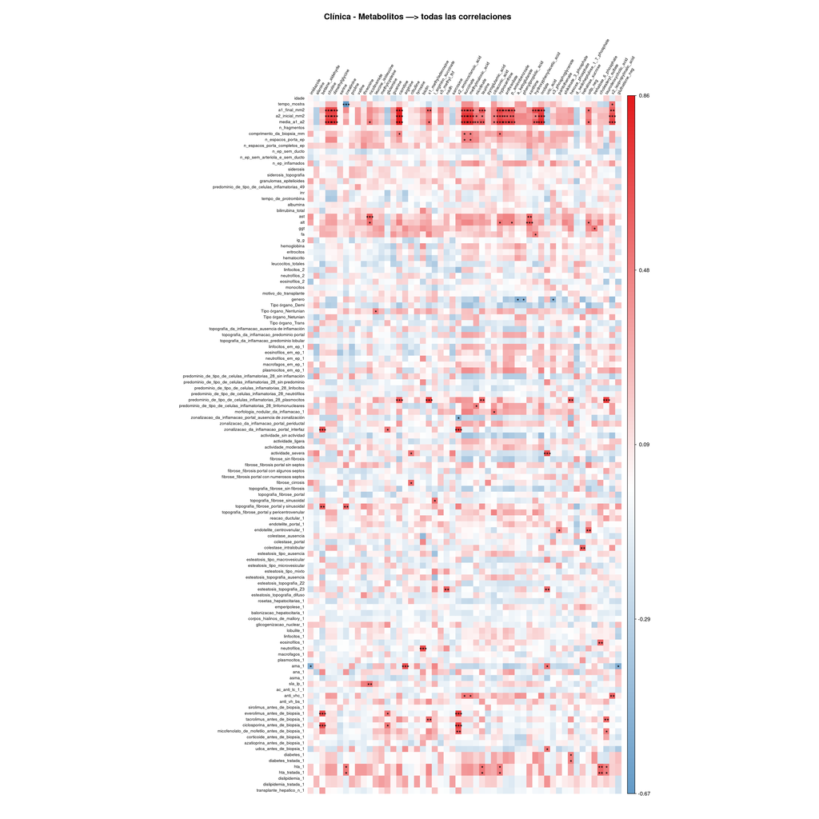

```r
par(mar = c(2, 2, 3, 1))
plot_corrblock(res_clin_met$r, res_clin_met$p,
               "Clínica - Metabolitos —> todas las correlaciones")
```

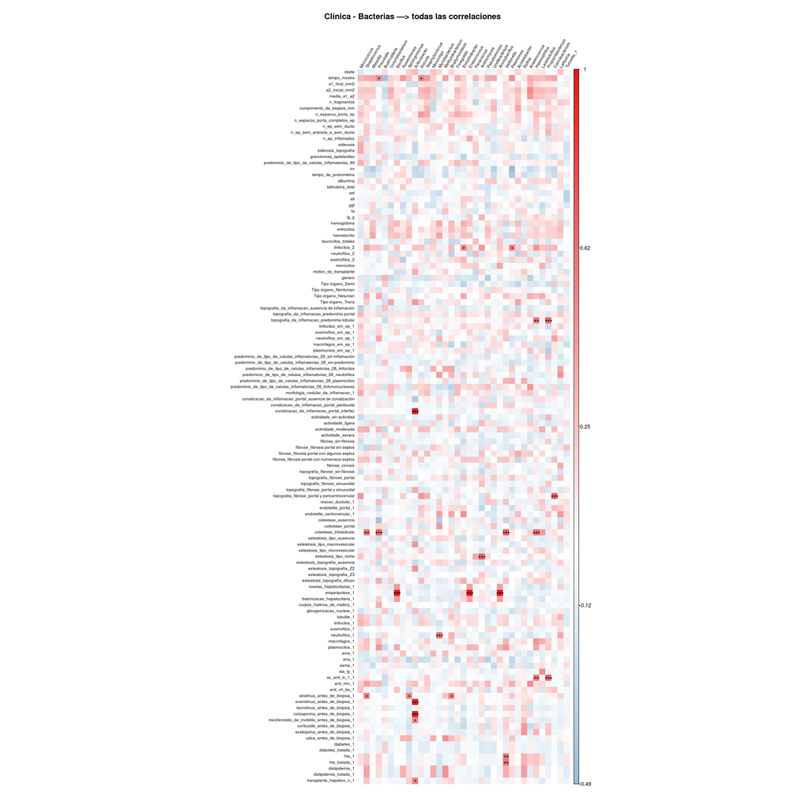

```r
par(mar = c(2, 2, 3, 1))
plot_corrblock(res_clin_bact$r, res_clin_bact$p,
               "Clínica - Bacterias —> todas las correlaciones")
```

Este mapa de correlación espacializa las **28 asociaciones significativas** identificadas entre las variables clínicas (filas) y los géneros bacterianos (columnas), mostrando una matriz mucho más dispersa y tenue que la observada con los metabolitos, lo que refleja un **vínculo más débil y localizado entre la clínica y el microbioma**. El gráfico está dominado por un fondo mayoritariamente blanco y de tonos muy pálidos, con asteriscos (`*`) puntuales que señalan interacciones muy específicas: destacan algunas correlaciones positivas (rojo) aisladas entre rasgos histológicos de daño tisular (como la **zonación de la inflamación** o la **presencia de esteatosis**) y taxones específicos, así como asociaciones discretas con variables demográficas o de tratamiento. Este patrón disperso confirma visualmente que, si bien existen **alteraciones en la microbiota ligadas al avance de las hepatopatías, estas no responden de manera masiva o uniforme a la gravedad de la enfermedad**, sino que se manifiestan a través de cambios puntuales en géneros específicos, conviviendo con una alta variabilidad individual.

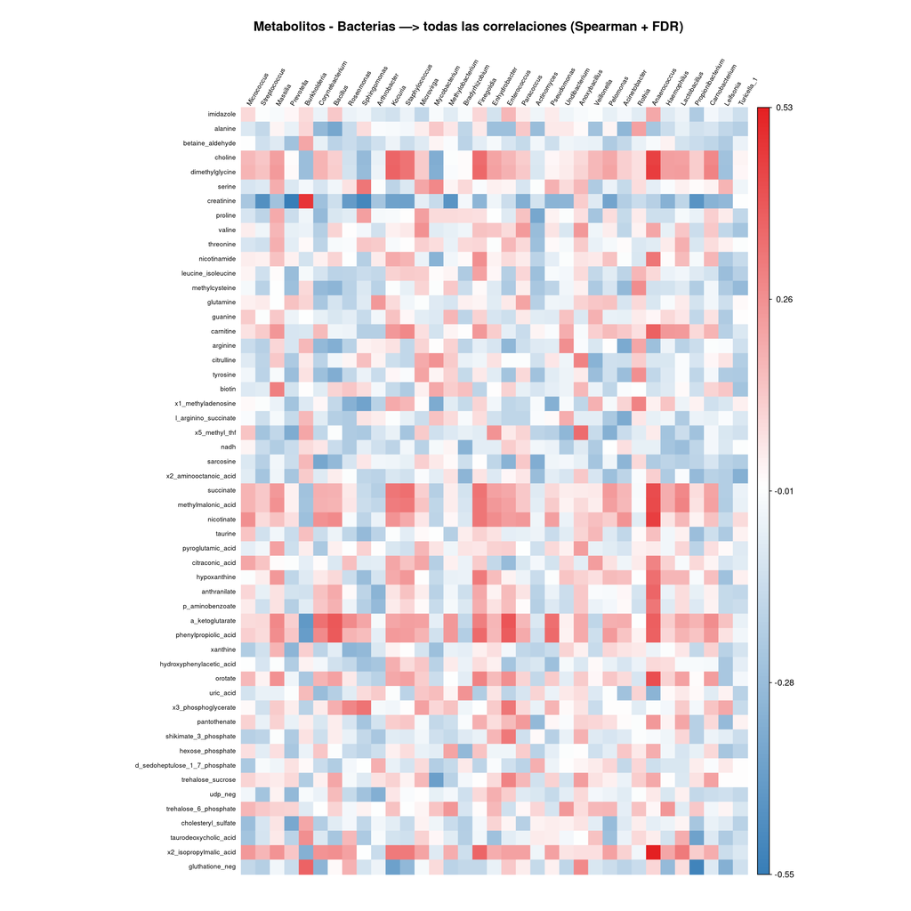

```r
par(mar = c(2, 2, 3, 1))
plot_corrblock(res_met_bact$r, p_adj_mb,
               "Metabolitos - Bacterias —> todas las correlaciones (Spearman + FDR)")
```

## Visualización de correlaciones significativas

Después, se generan mapas de calor reducidos que muestran únicamente las asociaciones estadísticamente significativas tras corrección FDR, permitiendo identificar de forma más clara las relaciones biológicamente relevantes entre variables clínicas, metabolitos y bacterias.

### Significativos Clínica - Metabolitos

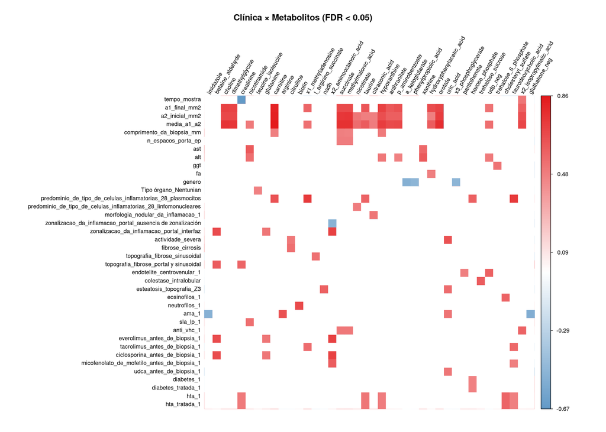

```r
par(mar = c(2, 2, 2, 1))
plot_corrblock_sig(res_clin_met$r, res_clin_met$p,
                   "Clínica × Metabolitos")
```

### Significativos Clínica - Bacterias

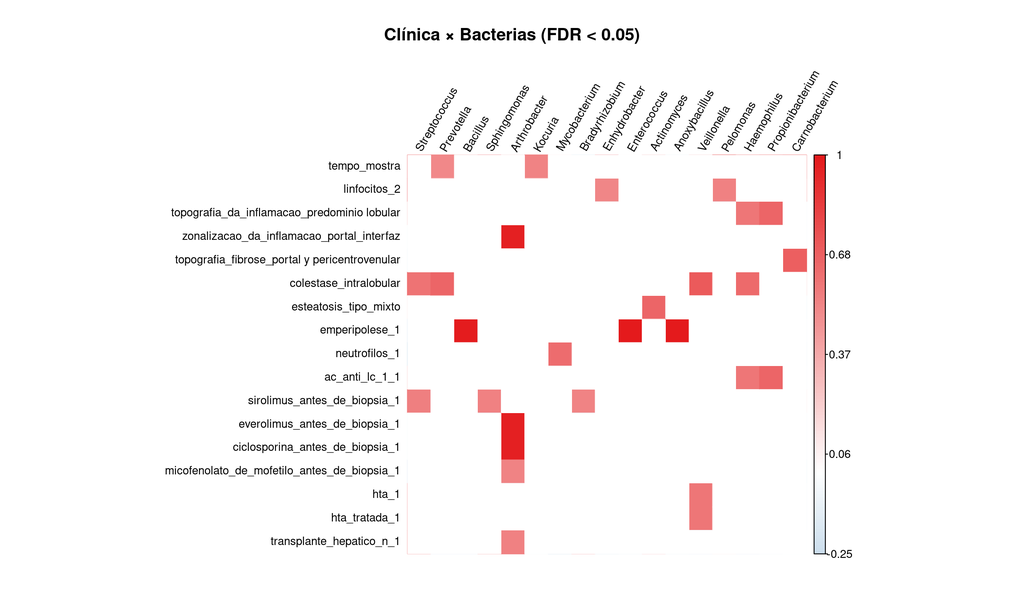

```r
par(mar = c(2, 2, 3, 1))
plot_corrblock_sig(res_clin_bact$r, res_clin_bact$p,
                   "Clínica × Bacterias")
```

Este mapa de calor filtrado expone las **28 asociaciones estadísticamente significativas (FDR < 0.05)** entre las variables clínicas y los géneros bacterianos, eliminando el ruido del análisis global. A diferencia de la masiva respuesta metabólica, aquí se observa un patrón de interacciones muy específico y fragmentado (todas de carácter positivo), donde destacan correlaciones clave; por ejemplo, la presencia de `colestase_intralobular` se asocia significativamente con los géneros *Streptococcus*, *Prevotella*, *Veillonella* y *Haemophilus*, mientras que procesos inflamatorios severos como la `emperipolese_1` o la inflamación en la interfaz portal correlacionan fuertemente con incrementos de *Bacillus*, *Enterococcus* y *Arthrobacter*. Asimismo, se evidencian huellas del impacto de la terapia inmunosupresora previa a la biopsia (con el uso de everolimus, ciclosporina o micofenolato) sobre el enriquecimiento de géneros específicos como *Arthrobacter*, confirmando que **el microbioma responde de manera puntual y dirigida tanto a nichos patofisiológicos específicos de la lesión hepática como a las intervenciones médicas recibidas**.